# ch02_Bike03_MultiModel_v12

## Kaggle 입문하기 - 데이터 분석 입문

### 학습 내용

- 데이터 시각화를 통해 피처를 추출을 해 봅니다.
- 다양한 모델을 활용 및 비교해 봅니다.
- 특성 자동 선택 클래스를 이용하여 중요한 특성을 추출해 봅니다.
- xgboost 모델을 활용해 봅니다.
  - 다양한 파라미터에 대해 알아봅니다.

### 목차

01 데이터 시각화 및 피처 추출  
02 생성된 특징을 활용한 모델 구축  
03 최종 모델 구축 및 제출  
04 추가 특징 생성 함수 이용하여 모델 구축  
05 자동 특징 추출 클래스  
06 대표적인 모델 xgboost 사용해보기

### Data Fields

| 필드명 | 설명 |
| --- | --- |
| datetime | hourly date + timestamp |
| season | 1 = spring(봄), 2 = summer(여름), 3 = fall(가을), 4 = winter(겨울) |
| holiday | whether the day is considered a holiday(휴일인지 아닌지) |
| workingday | whether the day is neither a weekend nor holiday(주말도 휴일도 아닌 날인지) |
| weather | 1: Clear, Few clouds, Partly cloudy, Partly cloudy 2: Mist + Cloudy, Mist + Broken clouds, Mist + Few clouds, Mist 3: Light Snow, Light Rain + Thunderstorm + Scattered clouds, Light Rain + Scattered c… |
| temp | temperature in Celsius (온도) |
| atemp | "feels like" temperature in Celsius (체감온도) |
| humidity | relative humidity (습도) |
| windspeed | wind speed (바람속도) |
| casual | number of non-registered user rentals initiated (비가입자 사용유저) |
| registered | number of registered user rentals initiated (가입자 사용유저) |
| count | number of total rentals (전체 렌탈 대수) |

### 01 데이터 시각화 및 피처 추출

```python
import pandas as pd
import matplotlib.pyplot as plt ## seaborn 보다 고급 시각화 가능. but 코드 복잡
import seaborn as sns           ## seaborn은 matplotlib보다 간단하게 사용 가능
import numpy as np              # 절대값, 수학함수 등
```

```python
train = pd.read_csv("../bike/train.csv", parse_dates=['datetime'])
test = pd.read_csv("../bike/test.csv", parse_dates=['datetime'])
```

### 범주형 특징(변수)의 시각화

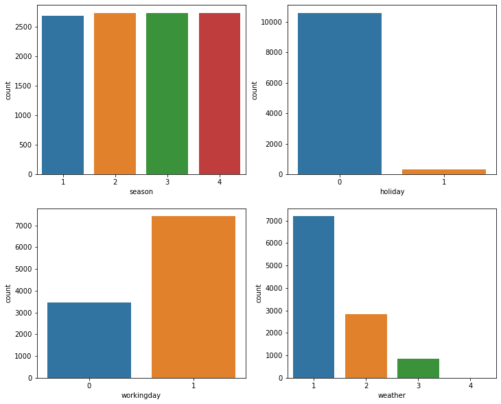

```python
col_names = [ 'season', 'holiday', 'workingday', 'weather'  ]
i = 0
plt.figure(figsize=(12,10))   # 전체 그래프의 크기 지정

for name in col_names:        # 컬럼명을 전달 리스트 수 만큼 반복 -> 4회
    i = i + 1                 # 숫자를 1씩 증가.
    plt.subplot(2,2,i)        # 2행 2열에 i번째 그래프 선택
    sns.countplot(x=name, data=train)  # i번째 그래프에 sns.countplot를 그리겠다.

plt.show()  # 주피터에서 보여주지만, 다른곳(editor, pycharm)에서는 이걸 실행시켜야 한다.
```

### 수치형 데이터 시각화

```python
### temp, atemp, humidity, windspeed

num_names = ['temp', 'atemp', 'humidity', 'windspeed']
train.columns
```

```
Index(['datetime', 'season', 'holiday', 'workingday', 'weather', 'temp',
       'atemp', 'humidity', 'windspeed', 'casual', 'registered', 'count'],
      dtype='object')
```

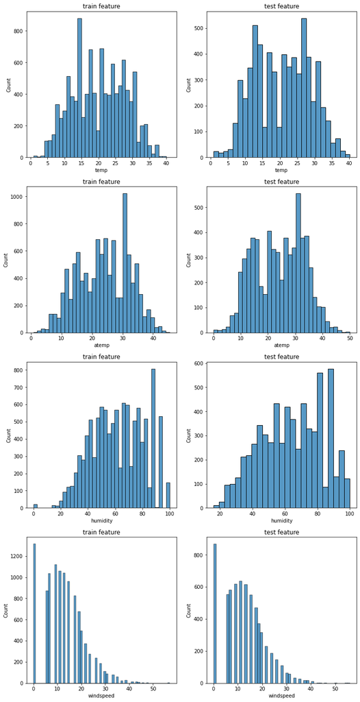

```python
i = 0
plt.figure(figsize=(12,25))   # 전체 그래프의 크기 지정 (가로, 세로)

for name in num_names:        # 컬럼명을 전달 리스트 수 만큼 반복 -> 4회
    i = i + 1                 # 숫자를 1씩 증가.
    plt.subplot(4,2,i*2-1)        # 2행 2열에 i번째 그래프 선택
    sns.histplot(x=name, data=train)  # i번째 그래프에 sns.histplot를 그리겠다.
    plt.title("train feature")

    plt.subplot(4,2,i*2)        # 2행 2열에 i번째 그래프 선택
    sns.histplot(x=name, data=test)  # i번째 그래프에 sns.histplot를 그리겠다.
    plt.title("test feature")

plt.show()
```

### 데이터 복제하기

```python
new_tr = train.copy()
new_test = test.copy()
new_tr.columns
```

```
Index(['datetime', 'season', 'holiday', 'workingday', 'weather', 'temp',
       'atemp', 'humidity', 'windspeed', 'casual', 'registered', 'count'],
      dtype='object')
```

### 특징 추출 - 날짜 특징(변수)로부터 정보 추출

- 날짜와 시간 변수(datetime)으로부터 년/월/일/시/분/초 등의 정보를 추출
- train 데이터 셋의 피처

```python
## 더미변수, 파생변수 생성
new_tr['year'] = new_tr['datetime'].dt.year
new_tr.head()
```

|  | datetime | season | holiday | workingday | weather | temp | atemp | humidity | windspeed | casual | registered | count | year |
| --- | --- | --- | --- | --- | --- | --- | --- | --- | --- | --- | --- | --- | --- |
| 0 | 2011-01-01 00:00:00 | 1 | 0 | 0 | 1 | 9.84 | 14.395 | 81 | 0.0 | 3 | 13 | 16 | 2011 |
| 1 | 2011-01-01 01:00:00 | 1 | 0 | 0 | 1 | 9.02 | 13.635 | 80 | 0.0 | 8 | 32 | 40 | 2011 |
| 2 | 2011-01-01 02:00:00 | 1 | 0 | 0 | 1 | 9.02 | 13.635 | 80 | 0.0 | 5 | 27 | 32 | 2011 |
| 3 | 2011-01-01 03:00:00 | 1 | 0 | 0 | 1 | 9.84 | 14.395 | 75 | 0.0 | 3 | 10 | 13 | 2011 |
| 4 | 2011-01-01 04:00:00 | 1 | 0 | 0 | 1 | 9.84 | 14.395 | 75 | 0.0 | 0 | 1 | 1 | 2011 |

```python
new_tr['month'] = new_tr['datetime'].dt.month
new_tr['day'] = new_tr['datetime'].dt.day
new_tr['hour'] = new_tr['datetime'].dt.hour
new_tr['minute'] = new_tr['datetime'].dt.minute
new_tr['second'] = new_tr['datetime'].dt.second
new_tr['dayofweek'] = new_tr['datetime'].dt.dayofweek
new_tr.head()
```

|  | datetime | season | holiday | workingday | weather | temp | atemp | humidity | windspeed | casual | registered | count | year | month | day | hour | minute | second | dayofweek |
| --- | --- | --- | --- | --- | --- | --- | --- | --- | --- | --- | --- | --- | --- | --- | --- | --- | --- | --- | --- |
| 0 | 2011-01-01 00:00:00 | 1 | 0 | 0 | 1 | 9.84 | 14.395 | 81 | 0.0 | 3 | 13 | 16 | 2011 | 1 | 1 | 0 | 0 | 0 | 5 |
| 1 | 2011-01-01 01:00:00 | 1 | 0 | 0 | 1 | 9.02 | 13.635 | 80 | 0.0 | 8 | 32 | 40 | 2011 | 1 | 1 | 1 | 0 | 0 | 5 |
| 2 | 2011-01-01 02:00:00 | 1 | 0 | 0 | 1 | 9.02 | 13.635 | 80 | 0.0 | 5 | 27 | 32 | 2011 | 1 | 1 | 2 | 0 | 0 | 5 |
| 3 | 2011-01-01 03:00:00 | 1 | 0 | 0 | 1 | 9.84 | 14.395 | 75 | 0.0 | 3 | 10 | 13 | 2011 | 1 | 1 | 3 | 0 | 0 | 5 |
| 4 | 2011-01-01 04:00:00 | 1 | 0 | 0 | 1 | 9.84 | 14.395 | 75 | 0.0 | 0 | 1 | 1 | 2011 | 1 | 1 | 4 | 0 | 0 | 5 |

```python
train.columns
```

```
Index(['datetime', 'season', 'holiday', 'workingday', 'weather', 'temp',
       'atemp', 'humidity', 'windspeed', 'casual', 'registered', 'count'],
      dtype='object')
```

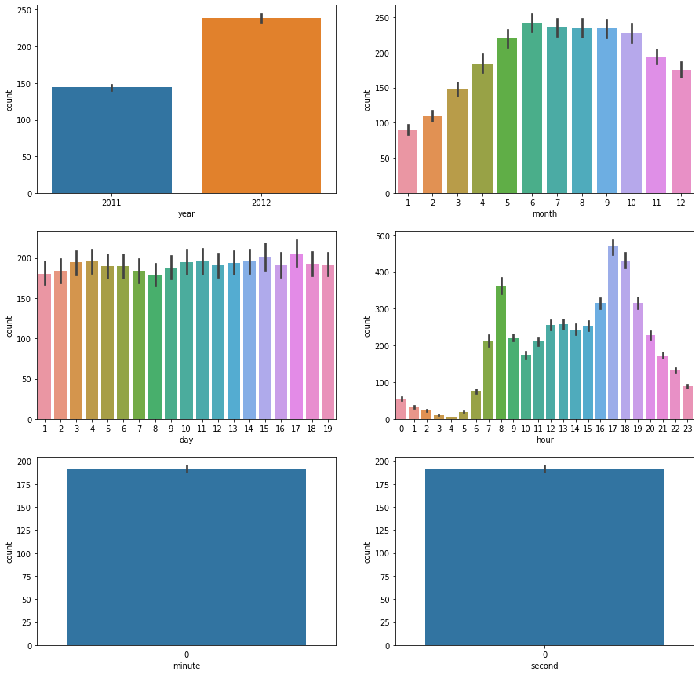

```python
datetime_names = ['year', 'month', 'day', 'hour', 'minute', 'second']

plt.figure(figsize=(15,15))
for idx, name in enumerate(datetime_names):
    plt.subplot(3,2,idx+1)
    sns.barplot(x=name, y='count', data=new_tr)

plt.show()
```

### 특징 추출 - 날짜 특징(변수)로부터 정보 추출

- 날짜와 시간 변수(datetime)으로부터 년/월/일/시/분/초 등의 정보를 추출
- test 데이터 셋의 피처

```python
new_test['year'] = new_test['datetime'].dt.year
new_test['month'] = new_test['datetime'].dt.month
new_test['day'] = new_test['datetime'].dt.day
new_test['dayofweek'] = new_test['datetime'].dt.dayofweek
new_test['hour'] = new_test['datetime'].dt.hour
new_test['minute'] = new_test['datetime'].dt.minute
new_test['second'] = new_test['datetime'].dt.second
```

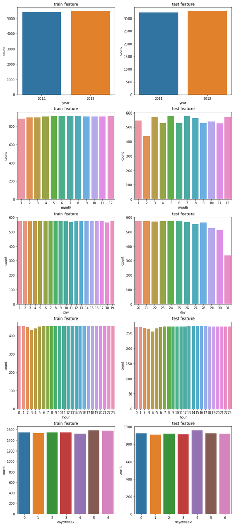

```python
col_names = ['year','month','day','hour','dayofweek']
i = 0
plt.figure(figsize=(12,35))  ##전체 그래프 크기 지정

for name in col_names: ## 컬럼명으로 반복
  i = i+1
  plt.subplot(6,2,i)  ##2행2열, i = 1,2,3,4 (왼쪽 상단부터 시계방향으로 순번 지정)
  sns.countplot(x = name, data = new_tr)
  plt.title("train feature")

  i = i+1
  plt.subplot(6,2,i)  ##2행2열, i = 1,2,3,4 (왼쪽 상단부터 시계방향으로 순번 지정)
  sns.countplot(x = name, data = new_test)
  plt.title("test feature")
plt.show()
```

```python
new_tr['dayofweek'] = new_tr['datetime'].dt.dayofweek  # Monday=0, Sunday=6
```

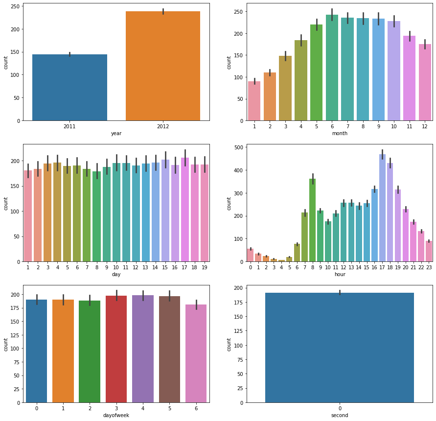

```python
datetime_names = ['year', 'month', 'day', 'hour', 'dayofweek', 'second']

i=0
plt.figure(figsize=(15,15))
for name in datetime_names:
    i = i + 1
    plt.subplot(3,2,i)
    sns.barplot(x=name, y='count', data=new_tr)

plt.show()
```

```python
print(new_test.shape)
new_test[["datetime", "year", "month", "day", "hour",
                   "minute", "second", "dayofweek"]].head()
```

```
(6493, 16)
```

|  | datetime | year | month | day | hour | minute | second | dayofweek |
| --- | --- | --- | --- | --- | --- | --- | --- | --- |
| 0 | 2011-01-20 00:00:00 | 2011 | 1 | 20 | 0 | 0 | 0 | 3 |
| 1 | 2011-01-20 01:00:00 | 2011 | 1 | 20 | 1 | 0 | 0 | 3 |
| 2 | 2011-01-20 02:00:00 | 2011 | 1 | 20 | 2 | 0 | 0 | 3 |
| 3 | 2011-01-20 03:00:00 | 2011 | 1 | 20 | 3 | 0 | 0 | 3 |
| 4 | 2011-01-20 04:00:00 | 2011 | 1 | 20 | 4 | 0 | 0 | 3 |

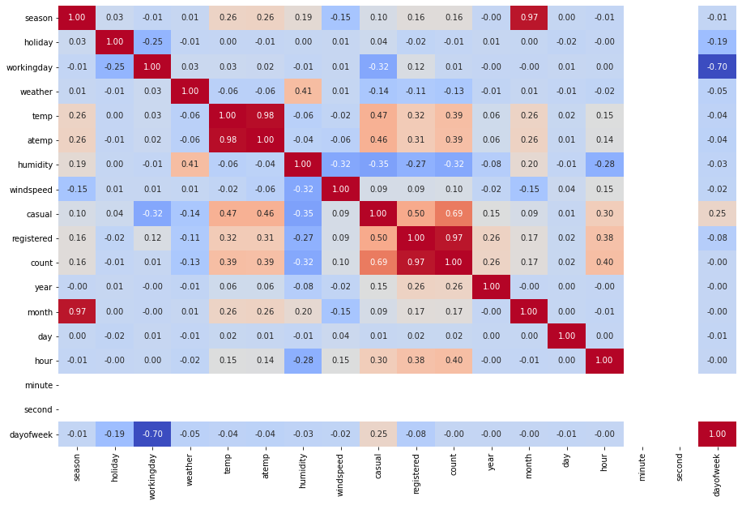

```python
plt.figure(figsize=(15,10))
g = sns.heatmap(new_tr.corr(), annot=True, fmt=".2f", cmap="coolwarm", cbar=False)
```

### 02 생성된 특징을 활용한 모델 구축

```python
feature_names = [ 'season', 'holiday', 'workingday', 'weather',
                  'temp', 'atemp', 'humidity', 'windspeed',
                  "year", "hour", "dayofweek"]  # 사용할 특징 선택

X_tr_all = new_tr[feature_names]      # 학습용 데이터 특징(변수) 선택
X_test_all = new_test[feature_names]  # 테스트 데이터의 특징(변수) 선택

X_tr_all.head()
```

|  | season | holiday | workingday | weather | temp | atemp | humidity | windspeed | year | hour | dayofweek |
| --- | --- | --- | --- | --- | --- | --- | --- | --- | --- | --- | --- |
| 0 | 1 | 0 | 0 | 1 | 9.84 | 14.395 | 81 | 0.0 | 2011 | 0 | 5 |
| 1 | 1 | 0 | 0 | 1 | 9.02 | 13.635 | 80 | 0.0 | 2011 | 1 | 5 |
| 2 | 1 | 0 | 0 | 1 | 9.02 | 13.635 | 80 | 0.0 | 2011 | 2 | 5 |
| 3 | 1 | 0 | 0 | 1 | 9.84 | 14.395 | 75 | 0.0 | 2011 | 3 | 5 |
| 4 | 1 | 0 | 0 | 1 | 9.84 | 14.395 | 75 | 0.0 | 2011 | 4 | 5 |

```python
label_name = 'count'                 # 렌탈 대수 (종속변수 or target)
y_tr_all = new_tr[label_name]        # 렌탈 대수 특징(변수) 선택
```

```python
from sklearn.model_selection import train_test_split
```

```python
X_train, X_test, y_train, y_test = train_test_split(X_tr_all,
                                                    y_tr_all,
                                                    test_size=0.3,
                                                    random_state=77)
```

### 선형 회귀 모델 구축

```python
from sklearn.linear_model import LinearRegression

model = LinearRegression()  # 모델 객체 생성.
model.fit(X_train, y_train)
pred = model.predict(X_test)

# 모델 평가 - 결정계수 확인
print("학습용 데이터 결정계수: {:.3f}".format(model.score(X_train, y_train)))
print("테스트 데이터 결정계수: {:.3f}".format(model.score(X_test, y_test)))

# MSE(mean squared error) 확인
mse_val = ( (pred - y_test) ** 2 ).sum() / len(pred)
print("mse value : {:.3f}".format(mse_val))
```

```
학습용 데이터 결정계수: 0.391
테스트 데이터 결정계수: 0.377
mse value : 20134.965
```

```python
from sklearn.tree import DecisionTreeRegressor

model = DecisionTreeRegressor()  # 모델 객체 생성.
model.fit(X_train, y_train)
pred = model.predict(X_test)

# 모델 평가 - 결정계수 확인
print("학습용 데이터 결정계수: {:.3f}".format(model.score(X_train, y_train)))
print("테스트 데이터 결정계수: {:.3f}".format(model.score(X_test, y_test)))

# MSE(mean squared error) 확인
mse_val = ( (pred - y_test) ** 2 ).sum() / len(pred)
print("mse value : {:.3f}".format(mse_val))
```

```
학습용 데이터 결정계수: 1.000
테스트 데이터 결정계수: 0.893
mse value : 3450.174
```

```python
from sklearn.ensemble import RandomForestRegressor   # 앙상블(의사결정트리 확장판)

seed = 37
model = RandomForestRegressor(n_jobs=-1, random_state=seed)  # 모델 객체 생성.
model.fit(X_train, y_train)           # 모델 학습(공부가 되었다.)
pred = model.predict(X_test)

# 결정계수 확인
print("학습용 데이터 결정계수: {:.3f}".format(model.score(X_train, y_train)))
print("테스트 데이터 결정계수: {:.3f}".format(model.score(X_test, y_test)))

# MSE(mean squared error) 확인
mse_val = ( (pred - y_test) ** 2 ).sum() / len(pred)
print("mse value : {:.3f}".format(mse_val))
```

```
학습용 데이터 결정계수: 0.992
테스트 데이터 결정계수: 0.946
mse value : 1752.403
```

```python
from sklearn.ensemble import GradientBoostingRegressor

seed = 37
model = GradientBoostingRegressor(random_state=seed)  # 모델 객체 생성.
model.fit(X_train, y_train)           # 모델 학습(공부가 되었다.)
pred = model.predict(X_test)

# 결정계수 확인
print("학습용 데이터 결정계수: {:.3f}".format(model.score(X_train, y_train)))
print("테스트 데이터 결정계수: {:.3f}".format(model.score(X_test, y_test)))

# MSE(mean squared error) 확인
mse_val = ( (pred - y_test) ** 2 ).sum() / len(pred)
print("mse value : {:.3f}".format(mse_val))
```

```
학습용 데이터 결정계수: 0.860
테스트 데이터 결정계수: 0.849
mse value : 4892.054
```

### RandomForestRegressor 모델의 mse의 값이 가장 적다. (오차가 적음)

### 03 최종 모델 구축 및 제출

```python
sub = pd.read_csv("../bike/sampleSubmission.csv")
sub.head()
```

|  | datetime | count |
| --- | --- | --- |
| 0 | 2011-01-20 00:00:00 | 0 |
| 1 | 2011-01-20 01:00:00 | 0 |
| 2 | 2011-01-20 02:00:00 | 0 |
| 3 | 2011-01-20 03:00:00 | 0 |
| 4 | 2011-01-20 04:00:00 | 0 |

```python
from sklearn.ensemble import RandomForestRegressor   # 앙상블(의사결정트리 확장판)

seed = 37
model = RandomForestRegressor(n_jobs=-1, random_state=seed)  # 모델 객체 생성.
model.fit(X_train, y_train)           # 모델 학습(공부가 되었다.)
```

```
RandomForestRegressor(n_jobs=-1, random_state=37)
```

- n_jobs = -1 : 사용 가능한 모든 core를 사용하겠다.

```python
pred = model.predict(X_test_all)   # 예측
sub['count'] = pred
sub.loc[sub['count'] < 0, 'count'] = 0
sub.head(3)
```

|  | datetime | count |
| --- | --- | --- |
| 0 | 2011-01-20 00:00:00 | 11.75 |
| 1 | 2011-01-20 01:00:00 | 4.20 |
| 2 | 2011-01-20 02:00:00 | 4.78 |

```python
# 처음 만는 제출용 csv 파일, 행번호를 없애기
sub.to_csv("third_sub.csv", index=False)
```

### 제출 score : 0.43006

### 04 추가 특징 생성 함수 이용하여 모델 구축

### 실습 : PolynomialFeatures를 사용하여 특징을 추가 생성해 보자.

```python
from sklearn.preprocessing import MinMaxScaler
from sklearn.preprocessing import PolynomialFeatures
```

```python
feature_names = [ 'season', 'holiday', 'workingday', 'weather',
                  'temp', 'atemp', 'humidity', 'windspeed',
                  "year", "hour", "dayofweek"]  # 공통 변수

X_tr_all = new_tr[feature_names]        # 학습용 데이터 변수 선택
X_test_all = new_test[feature_names]    # 테스트 데이터의 변수 선택
print(X_tr_all.head())
```

```
   season  holiday  workingday  weather  temp   atemp  humidity  windspeed  \
0       1        0           0        1  9.84  14.395        81        0.0
1       1        0           0        1  9.02  13.635        80        0.0
2       1        0           0        1  9.02  13.635        80        0.0
3       1        0           0        1  9.84  14.395        75        0.0
4       1        0           0        1  9.84  14.395        75        0.0

   year  hour  dayofweek
0  2011     0          5
1  2011     1          5
2  2011     2          5
3  2011     3          5
4  2011     4          5
```

```python
scaler = MinMaxScaler().fit(X_tr_all)

nor_X_tr_all = scaler.transform(X_tr_all)
ex_X_tr = PolynomialFeatures(degree=2,
                             include_bias=False).fit_transform(nor_X_tr_all)
y_tr_all = new_tr['count']
```

```python
X_train, X_test, y_train, y_test = train_test_split(ex_X_tr,
                                                   y_tr_all,
                                                   test_size=0.2,
                                                   random_state=42)
```

```python
def rmlse(predict, actual):
    log_y = np.log1p(predict)
    log_pred = np.log1p(actual)
    squared_error = (log_y - log_pred) ** 2
    rmsle_value = np.sqrt(np.mean(squared_error))
    return rmsle_value
```

```python
from sklearn.ensemble import RandomForestRegressor   # 앙상블(의사결정트리 확장판)

seed = 37
model = RandomForestRegressor(n_jobs=-1, random_state=seed)  # 모델 객체 생성.
model.fit(X_train, y_train)           # 모델 학습
pred = model.predict(X_test)

# 결정계수 확인
print("학습용 데이터 결정계수: {:.3f}".format(model.score(X_train, y_train)))
print("테스트 데이터 결정계수: {:.3f}".format(model.score(X_test, y_test)))

# MAE, MSE, RMSE, RMLSE
mae_val = ( np.abs(pred - y_test) ).sum() / len(pred)
mse_val = ( (pred - y_test)**2  ).sum() / len(pred)
rmse_val = np.sqrt( mse_val )
rmlse_val = rmlse(pred, y_test)

print("MAE : {:.3f}".format( mae_val ))
print("MSE : {:.3f}".format( mse_val ))
print("RMSE : {:.3f}".format( rmse_val ))
print("RMLSE : {:.3f}".format( rmlse_val ))
```

```
학습용 데이터 결정계수: 0.992
테스트 데이터 결정계수: 0.950
MAE : 25.784
MSE : 1659.031
RMSE : 40.731
RMLSE : 0.342
```

```python
nor_X_test_all = scaler.transform(X_test_all)
ex_X_test = PolynomialFeatures(degree=2,
                               include_bias=False).fit_transform(nor_X_test_all)
```

```python
pred = model.predict(ex_X_test)   # 예측
sub['count'] = pred
sub.loc[sub['count'] < 0, 'count'] = 0
sub.head(3)
```

|  | datetime | count |
| --- | --- | --- |
| 0 | 2011-01-20 00:00:00 | 13.66 |
| 1 | 2011-01-20 01:00:00 | 5.08 |
| 2 | 2011-01-20 02:00:00 | 3.53 |

```python
sub.to_csv("four_sub.csv", index=False)
```

### score : 0.41328

### 05 자동 특징 추출 클래스

### 다양한 특징 중에 모델을 활용한 중요한 특징을 선택해 보자.

```python
import warnings
warnings.filterwarnings(action='ignore')  # 경고 메시지 출력은 이제 그만
from sklearn.feature_selection import SelectFromModel
from sklearn.ensemble import RandomForestRegressor
```

```python
print(X_train.shape, y_train.shape)
```

```
(8708, 77) (8708,)
```

```python
select = SelectFromModel(RandomForestRegressor(n_estimators=100,
                                               random_state=37),
                                               threshold="0.1 * median")

select.fit(X_train, y_train)
```

```
SelectFromModel(estimator=RandomForestRegressor(random_state=37),
                threshold='0.1 * median')
```

- SelectFromModel은 모델 기반 특징 선택
- 지도학습 모델로 계산된 피처 중요도가 임계치(threshold)보다 큰 모든 특성을 선택

```python
X_train_l1 = select.transform(X_train)
X_test_l1 = select.transform(X_test)

X_train_l1.shape, X_test_l1.shape
```

```
((8708, 68), (2178, 68))
```

```
[ True False  True  True  True  True  True  True  True  True  True  True
 False  True  True  True  True  True  True  True  True  True False False
 False  True  True  True False False False False  True  True  True  True
  True  True  True  True  True  True  True  True  True  True  True  True
  True  True  True  True  True  True  True  True  True  True  True  True
  True  True  True  True  True  True  True  True  True  True  True  True
  True  True  True  True  True]
```

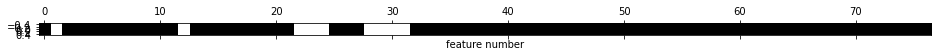

```python
### 어떤 특성이 선택되었는지 확인
mask = select.get_support()
print(mask)
plt.matshow(mask.reshape(1, -1), cmap='gray_r')
plt.xlabel("feature number")
```

```python
seed = 37
model = RandomForestRegressor(n_jobs=-1, random_state=seed)  # 모델 객체 생성.
model.fit(X_train_l1, y_train)           # 모델 학습
pred = model.predict(X_test_l1)

# MAE, MSE, RMSE, RMLSE
mae_val = ( np.abs(pred - y_test) ).sum() / len(pred)
mse_val = ( (pred - y_test)**2  ).sum() / len(pred)
rmse_val = np.sqrt( mse_val )
rmlse_val = rmlse(pred, y_test)

print("MAE : {:.3f}".format( mae_val ))
print("MSE : {:.3f}".format( mse_val ))
print("RMSE : {:.3f}".format( rmse_val ))
print("RMLSE : {:.3f}".format( rmlse_val ))
```

```
MAE : 25.675
MSE : 1644.395
RMSE : 40.551
RMLSE : 0.342
```

```python
X_test_l1_all = select.transform(ex_X_test)
X_test_l1_all.shape
```

```
(6493, 68)
```

```python
pred = model.predict(X_test_l1_all)
sub['count'] = pred
sub.loc[ sub['count'] <0 , 'count' ] =0
sub.to_csv('five_sub.csv', index=False)
```

### 06 대표적인 모델 xgboost 사용해 보기

```python
import xgboost as xgb
```

```python
### xgb.DMatrix
# * dense matrix, sparse matrix, local file로부터 DMatrix object 객체를 만든다.
# data_dmatrix = xgb.DMatrix(data=ex_X_tr,label=y_tr_all)
```

```python
X_train, X_test, y_train, y_test = train_test_split(ex_X_tr,
                                                    y_tr_all,
                                                    test_size=0.2,
                                                    random_state=42)
```

```python
# 기본 옵션 확인
xg_reg = xgb.XGBRegressor()
xg_reg
```

```
XGBRegressor(base_score=None, booster=None, callbacks=None,
             colsample_bylevel=None, colsample_bynode=None,
             colsample_bytree=None, early_stopping_rounds=None,
             enable_categorical=False, eval_metric=None, gamma=None,
             gpu_id=None, grow_policy=None, importance_type=None,
             interaction_constraints=None, learning_rate=None, max_bin=None,
             max_cat_to_onehot=None, max_delta_step=None, max_depth=None,
             max_leaves=None, min_child_weight=None, missing=nan,
             monotone_constraints=None, n_estimators=100, n_jobs=None,
             num_parallel_tree=None, predictor=None, random_state=None,
             reg_alpha=None, reg_lambda=None, ...)
```

### 사이킷런 기반 파라미터 설명

- 기본값은 사이킷런 기반 기본값

| 파라마터명 | 설명 | 사이킷런 기본값(파이썬기반) |
| --- | --- | --- |
| learning_rate(or eta) | 0~1사이의 값. 과적합을 방지하기 위한 학습률 값 | 기본값 : 0.1(0.3) |
| n_estimators(or num_boost_rounds) | **트리의 수** | 기본값 100(10) |
| max_depth | 각각의 나무 **모델의 최대 깊이** | 기본값 3(6) |
| subsample | 각 나무마다 사용하는 데이터 샘플 비율 낮은 값은 underfitting(과소적합)을 야기할 수 있음. | 기본값 : 1 |
| colsample_bytree | 각 나무마다 사용하는 **feature 비율**. High value can lead to overfitting. | 기본값 : 1 |
| reg_alpha(or alpha) | L1 규제에 대한 항 피처가 많을 수록 적용을 검토한다. | 기본값 : 0 |
| reg_lambda(or lambda) | L2 규제의 적용 값. 피처의 개수가 많을 경우 적용 검토 | 기본값 : 1 |
| scale_pos_weight | 불균형 데이터셋의 균형 유지 | 기본값 : 1 |

### 학습 태스크 파라미터

| 파라마터명 | 설명 | 사이킷런 기본값(파이썬기반) |
| --- | --- | --- |
| objective(목적함수) | **reg:linear** for regression problems(회귀 문제), **reg:logistic** for classification problems with only decision(분류 문제), **binary:logistic** for classification problems with probability.(이진 분류) |  |

```python
feature_names = [ 'season', 'holiday', 'workingday', 'weather',
                  'temp', 'atemp', 'humidity', 'windspeed',
                  "year", "hour", "dayofweek"]  # 공통 변수

X_tr_all = new_tr[feature_names]        # 학습용 데이터 변수 선택
X_test_all = new_test[feature_names]    # 테스트 데이터의 변수 선택
print(X_tr_all.head())
```

```
   season  holiday  workingday  weather  temp   atemp  humidity  windspeed  \
0       1        0           0        1  9.84  14.395        81        0.0
1       1        0           0        1  9.02  13.635        80        0.0
2       1        0           0        1  9.02  13.635        80        0.0
3       1        0           0        1  9.84  14.395        75        0.0
4       1        0           0        1  9.84  14.395        75        0.0

   year  hour  dayofweek
0  2011     0          5
1  2011     1          5
2  2011     2          5
3  2011     3          5
4  2011     4          5
```

```python
ex_X_tr = PolynomialFeatures(degree=2,
                             include_bias=False).fit_transform(X_tr_all)
y_tr_all = new_tr['count']

X_tr_all.shape, ex_X_tr.shape
```

```
((10886, 11), (10886, 77))
```

```python
X_train, X_test, y_train, y_test = train_test_split(ex_X_tr,
                                                   y_tr_all,
                                                   test_size=0.2,
                                                   random_state=42)
```

```python
xg_reg = xgb.XGBRegressor(objective ='reg:linear',
                          colsample_bytree = 0.3, # 각나무마다 사용하는 feature 비율
                          learning_rate = 0.1,
                          max_depth = 4,
                          alpha = 0.1,
                          n_estimators = 100)  # n_estimators=100
xg_reg
```

```
XGBRegressor(alpha=0.1, base_score=None, booster=None, callbacks=None,
             colsample_bylevel=None, colsample_bynode=None,
             colsample_bytree=0.3, early_stopping_rounds=None,
             enable_categorical=False, eval_metric=None, gamma=None,
             gpu_id=None, grow_policy=None, importance_type=None,
             interaction_constraints=None, learning_rate=0.1, max_bin=None,
             max_cat_to_onehot=None, max_delta_step=None, max_depth=4,
             max_leaves=None, min_child_weight=None, missing=nan,
             monotone_constraints=None, n_estimators=100, n_jobs=None,
             num_parallel_tree=None, objective='reg:linear', predictor=None,
             random_state=None, ...)
```

### 학습

```python
xg_reg.fit(X_train, y_train)
```

```
[16:15:33] WARNING: /Users/runner/work/xgboost/xgboost/python-package/build/temp.macosx-10.9-x86_64-3.7/xgboost/src/objective/regression_obj.cu:203: reg:linear is now deprecated in favor of reg:squarederror.
```

```
XGBRegressor(alpha=0.1, base_score=0.5, booster='gbtree', callbacks=None,
             colsample_bylevel=1, colsample_bynode=1, colsample_bytree=0.3,
             early_stopping_rounds=None, enable_categorical=False,
             eval_metric=None, gamma=0, gpu_id=-1, grow_policy='depthwise',
             importance_type=None, interaction_constraints='',
             learning_rate=0.1, max_bin=256, max_cat_to_onehot=4,
             max_delta_step=0, max_depth=4, max_leaves=0, min_child_weight=1,
             missing=nan, monotone_constraints='()', n_estimators=100, n_jobs=0,
             num_parallel_tree=1, objective='reg:linear', predictor='auto',
             random_state=0, ...)
```

```python
# 결정계수 확인
print("학습용 데이터 결정계수: {:.3f}".format(xg_reg.score(X_train, y_train)))
print("테스트 데이터 결정계수: {:.3f}".format(xg_reg.score(X_test, y_test)))
```

```
학습용 데이터 결정계수: 0.940
테스트 데이터 결정계수: 0.930
```

### 실습

- 나무의 개수를 조정해 보면서 확인해 보자.

```python
%%time

num_list = [100, 200, 300, 500, 1000, 1500, 2000, 3000]

for num in num_list:
    xg_reg = xgb.XGBRegressor(objective ='reg:linear',
            colsample_bytree = 0.3, # 각나무마다 사용하는 feature 비율
            learning_rate = 0.1,
            max_depth = 3,
            alpha = 0.1,
            n_estimators = num)
    xg_reg.fit(X_train, y_train)
    pred = xg_reg.predict(X_test)

    # MAE, MSE, RMSE, RMLSE
    mae_val = ( np.abs(pred - y_test) ).sum() / len(pred)
    mse_val = ( (pred - y_test)**2  ).sum() / len(pred)
    rmse_val = np.sqrt( mse_val )
    rmlse_val = rmlse(pred, y_test)

    print("MAE : {:.3f}".format( mae_val ))
    print("MSE : {:.3f}".format( mse_val ))
    print("RMSE : {:.3f}".format( rmse_val ))
    print("RMLSE : {:.3f}".format( rmlse_val ))
    print()
```

```
[16:15:34] WARNING: /Users/runner/work/xgboost/xgboost/python-package/build/temp.macosx-10.9-x86_64-3.7/xgboost/src/objective/regression_obj.cu:203: reg:linear is now deprecated in favor of reg:squarederror.
MAE : 39.436
MSE : 3376.439
RMSE : 58.107
RMLSE : 0.562

[16:15:35] WARNING: /Users/runner/work/xgboost/xgboost/python-package/build/temp.macosx-10.9-x86_64-3.7/xgboost/src/objective/regression_obj.cu:203: reg:linear is now deprecated in favor of reg:squarederror.
MAE : 34.143
MSE : 2515.522
RMSE : 50.155
RMLSE : 0.550

[16:15:36] WARNING: /Users/runner/work/xgboost/xgboost/python-package/build/temp.macosx-10.9-x86_64-3.7/xgboost/src/objective/regression_obj.cu:203: reg:linear is now deprecated in favor of reg:squarederror.
MAE : 31.513
MSE : 2189.830
RMSE : 46.796
RMLSE : 0.516

[16:15:39] WARNING: /Users/runner/work/xgboost/xgboost/python-package/build/temp.macosx-10.9-x86_64-3.7/xgboost/src/objective/regression_obj.cu:203: reg:linear is now deprecated in favor of reg:squarederror.
MAE : 28.937
MSE : 1894.832
RMSE : 43.530
RMLSE : 0.468

[16:15:43] WARNING: /Users/runner/work/xgboost/xgboost/python-package/build/temp.macosx-10.9-x86_64-3.7/xgboost/src/objective/regression_obj.cu:203: reg:linear is now deprecated in favor of reg:squarederror.
MAE : 26.922
MSE : 1665.535
RMSE : 40.811
RMLSE : 0.472

[16:15:50] WARNING: /Users/runner/work/xgboost/xgboost/python-package/build/temp.macosx-10.9-x86_64-3.7/xgboost/src/objective/regression_obj.cu:203: reg:linear is now deprecated in favor of reg:squarederror.
MAE : 26.258
MSE : 1597.554
RMSE : 39.969
RMLSE : 0.478

[16:16:03] WARNING: /Users/runner/work/xgboost/xgboost/python-package/build/temp.macosx-10.9-x86_64-3.7/xgboost/src/objective/regression_obj.cu:203: reg:linear is now deprecated in favor of reg:squarederror.
MAE : 25.982
MSE : 1566.315
RMSE : 39.577
RMLSE : 0.470

[16:16:21] WARNING: /Users/runner/work/xgboost/xgboost/python-package/build/temp.macosx-10.9-x86_64-3.7/xgboost/src/objective/regression_obj.cu:203: reg:linear is now deprecated in favor of reg:squarederror.
MAE : 25.899
MSE : 1556.697
RMSE : 39.455
RMLSE : 0.468

CPU times: user 3min 52s, sys: 2.51 s, total: 3min 54s
Wall time: 1min 19s
```

### 최종 모델

```python
xg_reg = xgb.XGBRegressor(objective ='reg:linear',
            colsample_bytree = 0.3, # 각나무마다 사용하는 feature 비율
            learning_rate = 0.05,
            max_depth = 5,
            alpha = 0.1,
            n_estimators = 3000)

xg_reg.fit(X_train, y_train)
print("학습용 세트 정확도: {:.3f}".format(xg_reg.score(X_train, y_train)))
print("테스트 세트 정확도: {:.3f}".format(xg_reg.score(X_test, y_test)))

# MAE, MSE, RMSE, RMLSE
mae_val = ( np.abs(pred - y_test) ).sum() / len(pred)
mse_val = ( (pred - y_test)**2  ).sum() / len(pred)
rmse_val = np.sqrt( mse_val )
rmlse_val = rmlse(pred, y_test)

print("MAE : {:.3f}".format( mae_val ))
print("MSE : {:.3f}".format( mse_val ))
print("RMSE : {:.3f}".format( rmse_val ))
print("RMLSE : {:.3f}".format( rmlse_val ))
```

```
[16:16:53] WARNING: /Users/runner/work/xgboost/xgboost/python-package/build/temp.macosx-10.9-x86_64-3.7/xgboost/src/objective/regression_obj.cu:203: reg:linear is now deprecated in favor of reg:squarederror.
학습용 세트 정확도: 0.998
테스트 세트 정확도: 0.959
MAE : 25.899
MSE : 1556.697
RMSE : 39.455
RMLSE : 0.468
```

```python
ex_X_test = PolynomialFeatures(degree=2,
                               include_bias=False).fit_transform(X_test_all)
```

```python
pred = xg_reg.predict(ex_X_test)   # 예측
sub['count'] = pred
sub.loc[sub['count'] < 0, 'count'] = 0
sub.head(3)
```

|  | datetime | count |
| --- | --- | --- |
| 0 | 2011-01-20 00:00:00 | 16.371508 |
| 1 | 2011-01-20 01:00:00 | 0.342722 |
| 2 | 2011-01-20 02:00:00 | 0.000000 |

```python
# 처음 만는 제출용 csv 파일, 행번호를 없애기
sub.to_csv("five_xgb_sub.csv", index=False)
```

- 제출 스코어 : 0.59553

### 파라미터를 변경해 가며 실습해보기 - 아래 각각의 경우에 대한 score확인해 보기

- lr_rate=0.1, max_depth = 4, 1000개 트리
- lr_rate=0.1, max_depth = 3, 1500개 트리
- lr_rate = 0.001, max_depth = 3, 1000개 트리
- lr_rate = 0.05, max_depth = 5, 500개 트리

### History

- 2021-10 update v12
- 2022-05 update v13 - rmlse, rmse, mae 추가

교육용으로 작성된 것으로 배포 및 복제시에 사전 허가가 필요합니다.  
Copyright 2021 LIM Co. all rights reserved.